# Prevendo Customer Churn em Operadoras de Telecom

## 1.0 - Definindo o problema de negócio

**Introdução:** Customer Churn (ou Rotatividade de Clientes, em uma tradução livre) refere-se a uma decisão tomada pelo cliente sobre o término do relacionamento comercial. Refere-se também à perda de clientes. A fidelidade do cliente e a rotatividade de clientes sempre somam 100%. Se uma empresa tem uma taxa de fidelidade de 60%, então a taxa de perda de clientes é de 40%. De acordo com a regra de lucratividade do cliente 80/20, 20% dos clientes estão gerando 80% da receita. Portanto, é muito importante prever os usuários que provavelmente abandonarão o relacionamento comercial e os fatores que afetam as decisões do cliente.

**Objetivo do Projeto:** Prever o Customer Churn em uma Operadora de Telecom. Criar um modelo de aprendizagem de máquina que possa prever se um cliente pode ou não cancelar seu plano e qual a probabilidade de ocorrer.

OBS: Esse é um projeto da formação Cientista de dados da Data Science Academy  
Fonte de dados: Disponibilizado na pasta "data" do projeto

## 2.0 - Carregar dataset, bibliotecas e funções

```python
# Bibliotecas
import pandas as pd
import numpy as np
import matplotlib.pyplot as plt
import seaborn as sns
import numpy as np
from scipy.stats import shapiro
from scipy.stats import chi2
from sklearn.preprocessing import LabelEncoder
from sklearn.preprocessing import StandardScaler
from sklearn.feature_selection import SelectKBest, f_classif
# !pip install imbalanced-learn
from imblearn.over_sampling import SMOTE
from sklearn.naive_bayes import GaussianNB
from sklearn.linear_model import LogisticRegression
from sklearn.neighbors import KNeighborsClassifier
from sklearn.svm import SVC
from sklearn.model_selection import KFold
from sklearn.model_selection import cross_validate
from sklearn.metrics import classification_report
from sklearn.ensemble import RandomForestClassifier
from sklearn.ensemble import GradientBoostingClassifier
# !pip install xgboost
from xgboost import XGBClassifier
from sklearn.model_selection import GridSearchCV
from sklearn.metrics import confusion_matrix
import pickle

# Config pandas
pd.set_option("max_columns", 1000)
```

```python
# Datasets
treino_raw = pd.read_csv("../data/telecom_treino.csv", sep = ",")
teste_raw = pd.read_csv("../data/telecom_teste.csv", sep = ",")
```

## 3.0 - Análise Exploratória de Dados

```python
# Primeiras linhas do dataset
treino_raw.head()
```

|  | Unnamed: 0 | state | account_length | area_code | international_plan | voice_mail_plan | number_vmail_messages | total_day_minutes | total_day_calls | total_day_charge | total_eve_minutes | total_eve_calls | total_eve_charge | total_night_minutes | total_night_calls | total_night_charge | total_intl_minutes | total_intl_calls | total_intl_charge | number_customer_service_calls | churn |
| --- | --- | --- | --- | --- | --- | --- | --- | --- | --- | --- | --- | --- | --- | --- | --- | --- | --- | --- | --- | --- | --- |
| 0 | 1 | KS | 128 | area_code_415 | no | yes | 25 | 265.1 | 110 | 45.07 | 197.4 | 99 | 16.78 | 244.7 | 91 | 11.01 | 10.0 | 3 | 2.70 | 1 | no |
| 1 | 2 | OH | 107 | area_code_415 | no | yes | 26 | 161.6 | 123 | 27.47 | 195.5 | 103 | 16.62 | 254.4 | 103 | 11.45 | 13.7 | 3 | 3.70 | 1 | no |
| 2 | 3 | NJ | 137 | area_code_415 | no | no | 0 | 243.4 | 114 | 41.38 | 121.2 | 110 | 10.30 | 162.6 | 104 | 7.32 | 12.2 | 5 | 3.29 | 0 | no |
| 3 | 4 | OH | 84 | area_code_408 | yes | no | 0 | 299.4 | 71 | 50.90 | 61.9 | 88 | 5.26 | 196.9 | 89 | 8.86 | 6.6 | 7 | 1.78 | 2 | no |
| 4 | 5 | OK | 75 | area_code_415 | yes | no | 0 | 166.7 | 113 | 28.34 | 148.3 | 122 | 12.61 | 186.9 | 121 | 8.41 | 10.1 | 3 | 2.73 | 3 | no |

A coluna "Unnamed: 0" pode ser removida do dataset porque é um índice e para o treinamento do modelo a coluna não tem relevância.  
As colunas categóricas e TARGET estão com o tipo de dados em String, será realizado um LabelEncoder (Transformação de categorias em valores numéricos) para melhor performance do modelo.

```python
# Dimensões do dataset
treino_raw.shape
```

```
(3333, 21)
```

O dataset tem um bom número de registro, porém tem que ter cuidado ao realizar remoção de registros para não afetar a performance do modelo.

```python
# Tipo de dado de cada atributo
treino_raw.dtypes
```

```
Unnamed: 0                         int64
state                             object
account_length                     int64
area_code                         object
international_plan                object
voice_mail_plan                   object
number_vmail_messages              int64
total_day_minutes                float64
total_day_calls                    int64
total_day_charge                 float64
total_eve_minutes                float64
total_eve_calls                    int64
total_eve_charge                 float64
total_night_minutes              float64
total_night_calls                  int64
total_night_charge               float64
total_intl_minutes               float64
total_intl_calls                   int64
total_intl_charge                float64
number_customer_service_calls      int64
churn                             object
dtype: object
```

Conforme visto anteriormente, o dataset tem algumas variáveis com o tipo Object (Strings) que representam variáveis categóricas, devem ser transformadas para números.

```python
# Valores missing
treino_raw.isna().sum()
```

```
Unnamed: 0                       0
state                            0
account_length                   0
area_code                        0
international_plan               0
voice_mail_plan                  0
number_vmail_messages            0
total_day_minutes                0
total_day_calls                  0
total_day_charge                 0
total_eve_minutes                0
total_eve_calls                  0
total_eve_charge                 0
total_night_minutes              0
total_night_calls                0
total_night_charge               0
total_intl_minutes               0
total_intl_calls                 0
total_intl_charge                0
number_customer_service_calls    0
churn                            0
dtype: int64
```

O dataset não contem valores missing.

```python
# Valores unicos de cada atributo
for i in treino_raw.columns:
    print(i, "-> ", treino_raw[i].nunique(), sep="")
```

```
Unnamed: 0-> 3333
state-> 51
account_length-> 212
area_code-> 3
international_plan-> 2
voice_mail_plan-> 2
number_vmail_messages-> 46
total_day_minutes-> 1667
total_day_calls-> 119
total_day_charge-> 1667
total_eve_minutes-> 1611
total_eve_calls-> 123
total_eve_charge-> 1440
total_night_minutes-> 1591
total_night_calls-> 120
total_night_charge-> 933
total_intl_minutes-> 162
total_intl_calls-> 21
total_intl_charge-> 162
number_customer_service_calls-> 10
churn-> 2
```

O dataset tem muitos valores unicos, o que indica que temos bastantes variáveis numéricas, pode-se fazer quantization das variáveis númericas para uma melhor performance do modelo

```python
# Separar atributos númericos e categóricos
variaveis_numericas = []
variaveis_categoricas = []

for i in treino_raw.columns:
    if ( treino_raw[i].dtype == 'O' ):
        variaveis_categoricas.append(i)
    else:
        variaveis_numericas.append(i)
```

```python
# Retirar o atributo "Unnamed: 0" da lista de variaveis numericas
variaveis_numericas.remove("Unnamed: 0")
```

### Variáveis numéricas

```python
# Sumário estatístico das variáveis numéricas
treino_raw[variaveis_numericas].describe()
```

|  | account_length | number_vmail_messages | total_day_minutes | total_day_calls | total_day_charge | total_eve_minutes | total_eve_calls | total_eve_charge | total_night_minutes | total_night_calls | total_night_charge | total_intl_minutes | total_intl_calls | total_intl_charge | number_customer_service_calls |
| --- | --- | --- | --- | --- | --- | --- | --- | --- | --- | --- | --- | --- | --- | --- | --- |
| count | 3333.000000 | 3333.000000 | 3333.000000 | 3333.000000 | 3333.000000 | 3333.000000 | 3333.000000 | 3333.000000 | 3333.000000 | 3333.000000 | 3333.000000 | 3333.000000 | 3333.000000 | 3333.000000 | 3333.000000 |
| mean | 101.064806 | 8.099010 | 179.775098 | 100.435644 | 30.562307 | 200.980348 | 100.114311 | 17.083540 | 200.872037 | 100.107711 | 9.039325 | 10.237294 | 4.479448 | 2.764581 | 1.562856 |
| std | 39.822106 | 13.688365 | 54.467389 | 20.069084 | 9.259435 | 50.713844 | 19.922625 | 4.310668 | 50.573847 | 19.568609 | 2.275873 | 2.791840 | 2.461214 | 0.753773 | 1.315491 |
| min | 1.000000 | 0.000000 | 0.000000 | 0.000000 | 0.000000 | 0.000000 | 0.000000 | 0.000000 | 23.200000 | 33.000000 | 1.040000 | 0.000000 | 0.000000 | 0.000000 | 0.000000 |
| 25% | 74.000000 | 0.000000 | 143.700000 | 87.000000 | 24.430000 | 166.600000 | 87.000000 | 14.160000 | 167.000000 | 87.000000 | 7.520000 | 8.500000 | 3.000000 | 2.300000 | 1.000000 |
| 50% | 101.000000 | 0.000000 | 179.400000 | 101.000000 | 30.500000 | 201.400000 | 100.000000 | 17.120000 | 201.200000 | 100.000000 | 9.050000 | 10.300000 | 4.000000 | 2.780000 | 1.000000 |
| 75% | 127.000000 | 20.000000 | 216.400000 | 114.000000 | 36.790000 | 235.300000 | 114.000000 | 20.000000 | 235.300000 | 113.000000 | 10.590000 | 12.100000 | 6.000000 | 3.270000 | 2.000000 |
| max | 243.000000 | 51.000000 | 350.800000 | 165.000000 | 59.640000 | 363.700000 | 170.000000 | 30.910000 | 395.000000 | 175.000000 | 17.770000 | 20.000000 | 20.000000 | 5.400000 | 9.000000 |

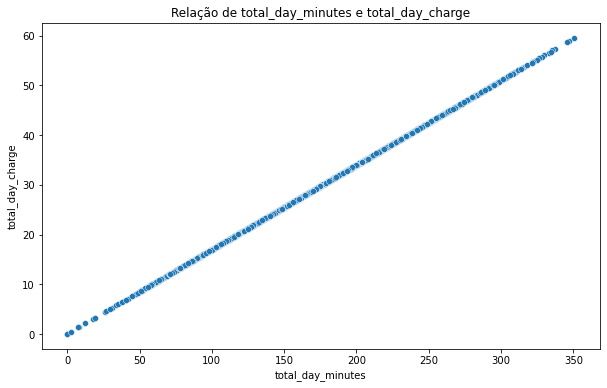

```python
# Gráfico de dispersão entre as variáveis total_day_minutes e total_day_charge
fig = plt.figure(figsize=(10,6))
sns.scatterplot(data = treino_raw[variaveis_numericas], x = "total_day_minutes", y = "total_day_charge")
plt.title("Relação de total_day_minutes e total_day_charge")
plt.show()
```

De acordo com o scatterplot, temos uma correlação positiva das variáveis, conforme cresce os minutos falados no dia, sobe o custo.

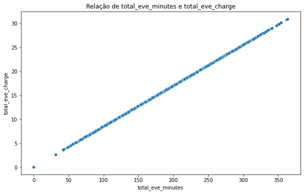

```python
# Gráfico de dispersão entre as variáveis total_eve_minutes e total_eve_charge
fig = plt.figure(figsize=(10,6))
sns.scatterplot(data = treino_raw[variaveis_numericas], x = "total_eve_minutes", y = "total_eve_charge")
plt.title("Relação de total_eve_minutes e total_eve_charge")
plt.show()
```

De acordo com o scatterplot, temos uma correlação positiva das variáveis, conforme cresce os minutos falados na vespera, sobe o custo, porém o custo é menor do que os minutos falados no dia e custo do dia.

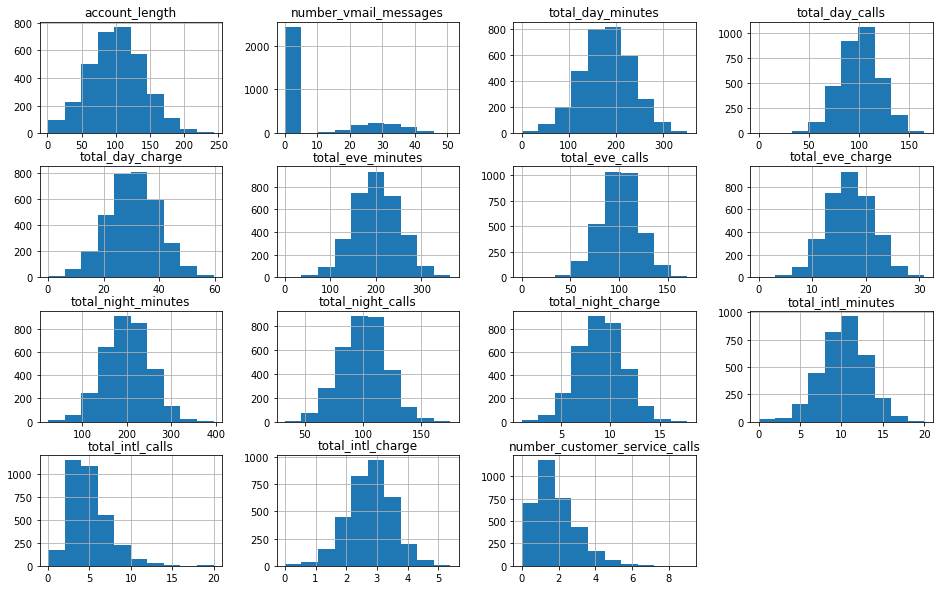

```python
# Histograma
treino_raw[variaveis_numericas].hist(figsize=(16,10))
plt.show()
```

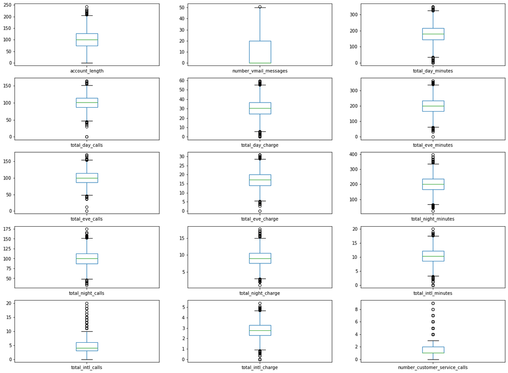

```python
# Boxplot
treino_raw[variaveis_numericas].plot(kind='box', layout=(5,3), subplots=True, figsize=(20,15))
plt.show()
```

De acordo com os boxplots, todas as variáveis numéricas tem valores outliers, a maioria dos outliers estão concentrados no 1º e 3º quartil.

```python
# Teste de hipótese para validar distribuição gaussiana
# H0 -> É uma distribuição gaussiana
# Ha -> Não é uma distribuição gaussiana
def teste_gaussiano(nome_variavel, dados_variavel):
    alpha = 0.05
    stat, p = shapiro(dados_variavel)

    if p > alpha:
        print("Variável", nome_variavel, "está em uma distribuição gaussiana (Falha ao rejeitar H0)")
        print("\tP-Value: %.3f" % p)
    else:
        print("Variável", nome_variavel, "não está em uma distribuição gaussiana (Rejeitar H0)")
        print("\tP-Value: %.3f" % p)
    print()
```

```python
for i in variaveis_numericas:
    teste_gaussiano(i, treino_raw[i])
```

```
Variável account_length não está em uma distribuição gaussiana (Rejeitar H0)
	P-Value: 0.001

Variável number_vmail_messages não está em uma distribuição gaussiana (Rejeitar H0)
	P-Value: 0.000

Variável total_day_minutes está em uma distribuição gaussiana (Falha ao rejeitar H0)
	P-Value: 0.637

Variável total_day_calls não está em uma distribuição gaussiana (Rejeitar H0)
	P-Value: 0.000

Variável total_day_charge está em uma distribuição gaussiana (Falha ao rejeitar H0)
	P-Value: 0.641

Variável total_eve_minutes está em uma distribuição gaussiana (Falha ao rejeitar H0)
	P-Value: 0.711

Variável total_eve_calls não está em uma distribuição gaussiana (Rejeitar H0)
	P-Value: 0.009

Variável total_eve_charge está em uma distribuição gaussiana (Falha ao rejeitar H0)
	P-Value: 0.704

Variável total_night_minutes está em uma distribuição gaussiana (Falha ao rejeitar H0)
	P-Value: 0.623

Variável total_night_calls está em uma distribuição gaussiana (Falha ao rejeitar H0)
	P-Value: 0.250

Variável total_night_charge está em uma distribuição gaussiana (Falha ao rejeitar H0)
	P-Value: 0.620

Variável total_intl_minutes não está em uma distribuição gaussiana (Rejeitar H0)
	P-Value: 0.000

Variável total_intl_calls não está em uma distribuição gaussiana (Rejeitar H0)
	P-Value: 0.000

Variável total_intl_charge não está em uma distribuição gaussiana (Rejeitar H0)
	P-Value: 0.000

Variável number_customer_service_calls não está em uma distribuição gaussiana (Rejeitar H0)
	P-Value: 0.000
```

Algumas variáveis não estão em uma distribuição normal, será realizado normalização nas variáveis para melhor performance do modelo preditivo.

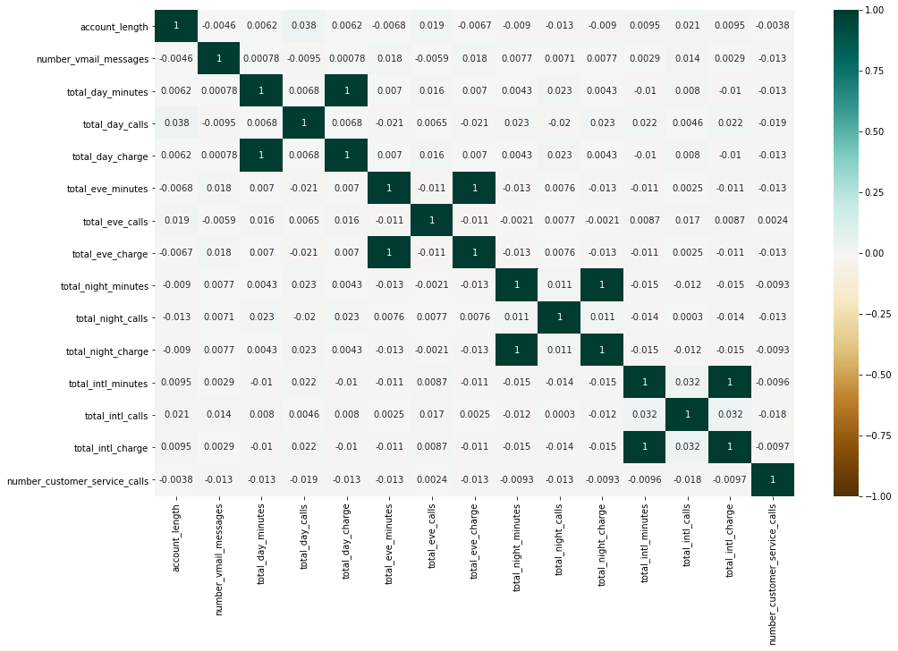

```python
# Correlação das variáveis numéricas
figure = plt.figure(figsize=(16,10))
sns.heatmap(treino_raw[variaveis_numericas].corr(),
            cmap='BrBG', vmin=-1, vmax=1, annot=True)
plt.show()
```

O dataset tem poucas variáveis correlacionadas, porém as correlações existentes são fortes.

```python
# Simetria das variáveis numéricas
treino_raw[variaveis_numericas].skew()
```

```
account_length                   0.096606
number_vmail_messages            1.264824
total_day_minutes               -0.029077
total_day_calls                 -0.111787
total_day_charge                -0.029083
total_eve_minutes               -0.023877
total_eve_calls                 -0.055563
total_eve_charge                -0.023858
total_night_minutes              0.008921
total_night_calls                0.032500
total_night_charge               0.008886
total_intl_minutes              -0.245136
total_intl_calls                 1.321478
total_intl_charge               -0.245287
number_customer_service_calls    1.091359
dtype: float64
```

### Variáveis categóricas

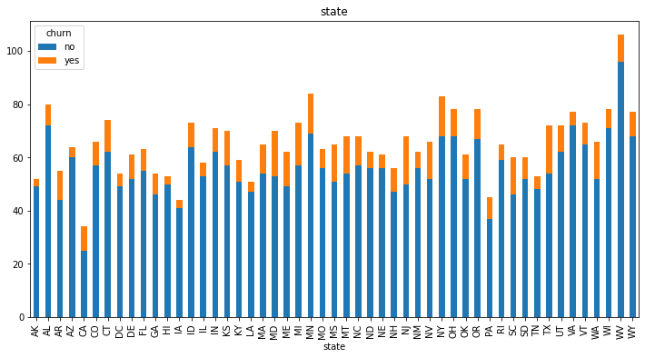

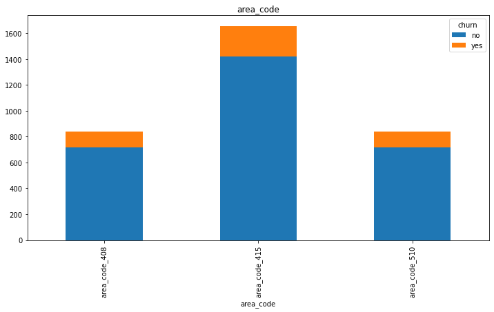

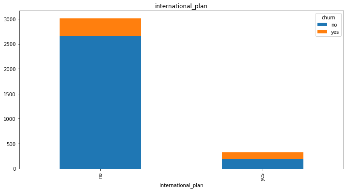

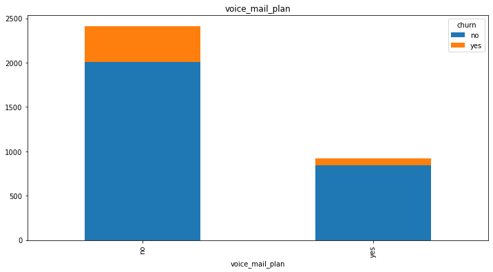

```python
# Barplot de cada variável agrupado pela variável TARGET (Churn)
for i in treino_raw[variaveis_categoricas].drop("churn", axis = 1).columns:
    pd.crosstab(treino_raw[i], treino_raw["churn"]).plot(kind = "bar",
                                                         stacked = True,
                                                         figsize = (12,6),
                                                         title = i)
```

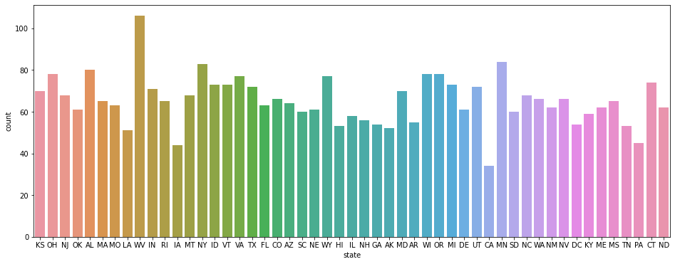

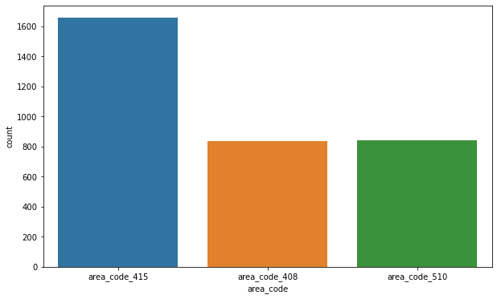

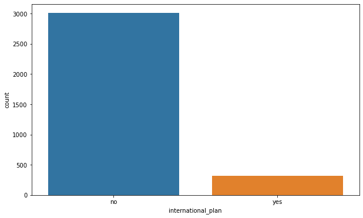

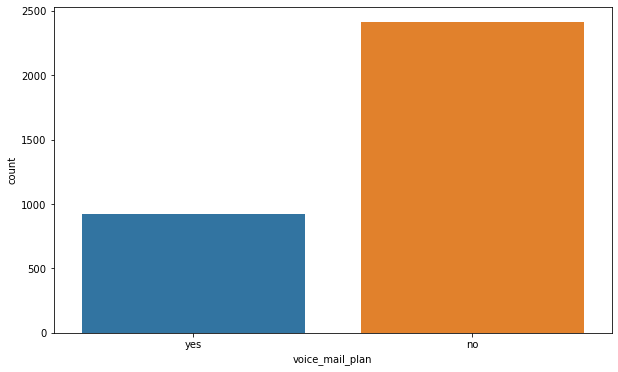

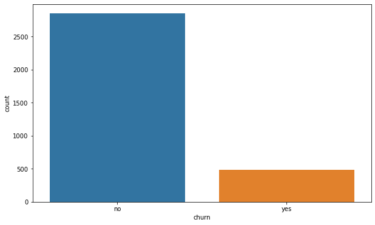

```python
# Countplot para contar os valores das variáveis categóricas
for i in variaveis_categoricas:
    if ( i == "state" ):
        val_figsize = (16,6)
    else:
        val_figsize = (10,6)

    fig = plt.figure(figsize=val_figsize)
    sns.countplot(x = i, data = treino_raw)
    plt.show()
```

De acordo com os gráfico de barras, os estados com mais registros são WV e MN, o código de área com mais registro é area_code_415, a maioria dos registros não tem plano internacional e não tem plano de correio de voz. A variável TARGET (churn) está desbalanceada, tem mais de 2500 registros com churn no e aproximadamente 500 registros com churn yes, para melhor performance do modelo preditivo, precisa-se balancear a variável churn.

```python
# Label Encoder das variáveis categóricas para realizar análise de correlação
treino_raw_le = treino_raw.copy()

for i in variaveis_categoricas:
    print("Realizando label encoder da variável", i)
    le = LabelEncoder()
    le.fit(treino_raw[i])
    treino_raw_le[i] = le.transform(treino_raw_le[i])
```

```
Realizando label encoder da variável state
Realizando label encoder da variável area_code
Realizando label encoder da variável international_plan
Realizando label encoder da variável voice_mail_plan
Realizando label encoder da variável churn
```

```python
# Exibir primeiras linhas do dataset depois do labelencoder das variáveis categóricas
treino_raw_le.head()
```

|  | Unnamed: 0 | state | account_length | area_code | international_plan | voice_mail_plan | number_vmail_messages | total_day_minutes | total_day_calls | total_day_charge | total_eve_minutes | total_eve_calls | total_eve_charge | total_night_minutes | total_night_calls | total_night_charge | total_intl_minutes | total_intl_calls | total_intl_charge | number_customer_service_calls | churn |
| --- | --- | --- | --- | --- | --- | --- | --- | --- | --- | --- | --- | --- | --- | --- | --- | --- | --- | --- | --- | --- | --- |
| 0 | 1 | 16 | 128 | 1 | 0 | 1 | 25 | 265.1 | 110 | 45.07 | 197.4 | 99 | 16.78 | 244.7 | 91 | 11.01 | 10.0 | 3 | 2.70 | 1 | 0 |
| 1 | 2 | 35 | 107 | 1 | 0 | 1 | 26 | 161.6 | 123 | 27.47 | 195.5 | 103 | 16.62 | 254.4 | 103 | 11.45 | 13.7 | 3 | 3.70 | 1 | 0 |
| 2 | 3 | 31 | 137 | 1 | 0 | 0 | 0 | 243.4 | 114 | 41.38 | 121.2 | 110 | 10.30 | 162.6 | 104 | 7.32 | 12.2 | 5 | 3.29 | 0 | 0 |
| 3 | 4 | 35 | 84 | 0 | 1 | 0 | 0 | 299.4 | 71 | 50.90 | 61.9 | 88 | 5.26 | 196.9 | 89 | 8.86 | 6.6 | 7 | 1.78 | 2 | 0 |
| 4 | 5 | 36 | 75 | 1 | 1 | 0 | 0 | 166.7 | 113 | 28.34 | 148.3 | 122 | 12.61 | 186.9 | 121 | 8.41 | 10.1 | 3 | 2.73 | 3 | 0 |

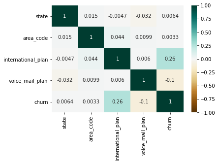

```python
# Análise de correlação com Spearman
sns.heatmap(treino_raw_le[variaveis_categoricas].corr(method="spearman"),
            cmap='BrBG', vmin=-1, vmax=1, annot=True)
plt.show()
```

Realizado LabelEncoder nas variáveis para realizar análise de correlação. A correlação das variáveis preditoras com a variável target é fraca, muito próxima de zero, a variável preditora que tem mais correlação com a variável target é International_Plan.

## 4.0 - Manipulação de dados

```python
# Cópia do dataset original para efetuar as manipulações
treino_munging = treino_raw.copy()
```

Declarar função para estruturar e manipular os dados do dataset para treinar o modelo de machine learning.  
As técnicas utilizadas dentro da função "estruturar_dados" foram criadas de acordo com as necessidades descobertas na análise exploratória.

```python
# Declarar e Treinar LabelEncoder para cada variável categorica
le = []

# Adicionar cada variável categorica no LabelEncoder
for i in variaveis_categoricas:
    le.append((i, LabelEncoder()))

# Treinar LabelEncoder de cada variável categórica
for var, modelo in le:
    modelo.fit(treino_munging[var])
    print("Concluído LabelEncoder da variável", var)
```

```
Concluído LabelEncoder da variável state
Concluído LabelEncoder da variável area_code
Concluído LabelEncoder da variável international_plan
Concluído LabelEncoder da variável voice_mail_plan
Concluído LabelEncoder da variável churn
```

```python
# Função para realizar a manipulação dos dados
standard_scaler = StandardScaler()

def tratar_dados(dataset):
    # Remover variável "Unnamed: 0" do dataset
    try:
        dataset = dataset.drop(["Unnamed: 0"], axis = 1)
        print("Concluído remoção da variável 'Unnamed: 0'")
    except:
        print("O dataset não tem a variável 'Unnamed: 0'")

    # Transformar variáveis categóricas que estão em formato de texto para número
    for var, modelo in le:
        try:
            dataset[var] = modelo.fit_transform(dataset[var])
            print("Concluído LabelEncoder da variável", var)
        except:
            print("O dataset não tem a variável", var)

    # Normalizar as variáveis numéricas
    dataset[variaveis_numericas] = standard_scaler.fit_transform(X = dataset[variaveis_numericas], y = dataset["churn"])
    print("Concluído normalização das variáveis numéricas")

    return dataset

# Função para inverter o label encoder das variáveis categóricas e normalização das variáveis numéricas
def inverter_dados(dataset):
    # Transformar variáveis categóricas que estão em formato de texto para número
    for var, modelo in le:
        try:
            dataset[var] = modelo.inverse_transform(dataset[var])
            print("Concluído inversão de LabelEncoder da variável", var)
        except:
            print("O dataset não tem a variável", var)

    # Normalizar as variáveis numéricas
    dataset[variaveis_numericas] = standard_scaler.inverse_transform(X = dataset[variaveis_numericas])

    return dataset
```

```python
# Utilizar a função para realizar a manipulação dos dados (Remover variável "Unnamed: 0", tranformar variáveis categóricas que
# estão em formato texto para número e normalizar as variáveis númericas)
treino_munging = tratar_dados(treino_munging)
```

```
Concluído remoção da variável 'Unnamed: 0'
Concluído LabelEncoder da variável state
Concluído LabelEncoder da variável area_code
Concluído LabelEncoder da variável international_plan
Concluído LabelEncoder da variável voice_mail_plan
Concluído LabelEncoder da variável churn
Concluído normalização das variáveis numéricas
```

```python
# Exibir primeiras linhas do dataset manipulado
treino_munging.head()
```

|  | state | account_length | area_code | international_plan | voice_mail_plan | number_vmail_messages | total_day_minutes | total_day_calls | total_day_charge | total_eve_minutes | total_eve_calls | total_eve_charge | total_night_minutes | total_night_calls | total_night_charge | total_intl_minutes | total_intl_calls | total_intl_charge | number_customer_service_calls | churn |
| --- | --- | --- | --- | --- | --- | --- | --- | --- | --- | --- | --- | --- | --- | --- | --- | --- | --- | --- | --- | --- |
| 0 | 16 | 0.676489 | 1 | 0 | 1 | 1.234883 | 1.566767 | 0.476643 | 1.567036 | -0.070610 | -0.055940 | -0.070427 | 0.866743 | -0.465494 | 0.866029 | -0.085008 | -0.601195 | -0.085690 | -0.427932 | 0 |
| 1 | 35 | 0.149065 | 1 | 0 | 1 | 1.307948 | -0.333738 | 1.124503 | -0.334013 | -0.108080 | 0.144867 | -0.107549 | 1.058571 | 0.147825 | 1.059390 | 1.240482 | -0.601195 | 1.241169 | -0.427932 | 0 |
| 2 | 31 | 0.902529 | 1 | 0 | 0 | -0.591760 | 1.168304 | 0.675985 | 1.168464 | -1.573383 | 0.496279 | -1.573900 | -0.756869 | 0.198935 | -0.755571 | 0.703121 | 0.211534 | 0.697156 | -1.188218 | 0 |
| 3 | 35 | -0.428590 | 0 | 1 | 0 | -0.591760 | 2.196596 | -1.466936 | 2.196759 | -2.742865 | -0.608159 | -2.743268 | -0.078551 | -0.567714 | -0.078806 | -1.303026 | 1.024263 | -1.306401 | 0.332354 | 0 |
| 4 | 36 | -0.654629 | 1 | 1 | 0 | -0.591760 | -0.240090 | 0.626149 | -0.240041 | -1.038932 | 1.098699 | -1.037939 | -0.276311 | 1.067803 | -0.276562 | -0.049184 | -0.601195 | -0.045885 | 1.092641 | 0 |

O dataset está com as variáveis categóricas transformadas para número e as variáveis numéricas estão normalizadas, mas será que essas variáveis numéricas estão mesmo normalizadas? Vamos plotar histograma para confirmar.

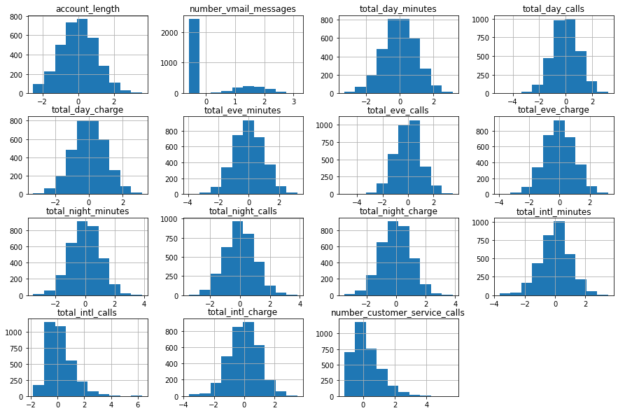

```python
# Histograma das variáveis numéricas
treino_munging[variaveis_numericas].hist(figsize=(15,10))
plt.show()
```

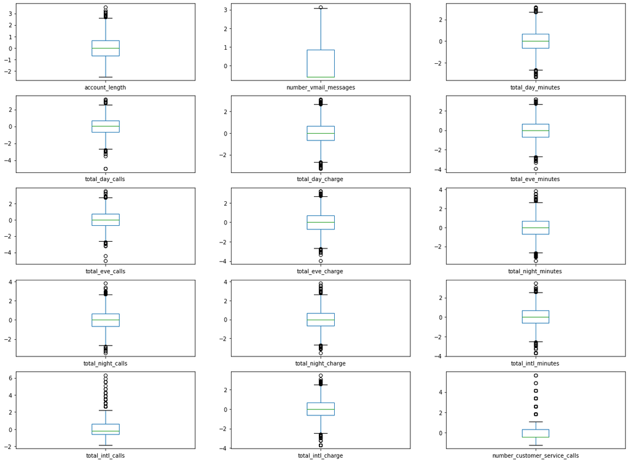

```python
# Boxplot das variáveis numéricas
treino_munging[variaveis_numericas].plot(kind='box', layout=(5,3), subplots=True, figsize=(20,15))
plt.show()
```

De acordo com os graficos exibidos acima, as variáveis númericas do dataset tem muitos outliers, será realizado remoção dos outliers.

```python
# Função para remover outlier da variável com método do desvio padrão
def remover_outlier(valor):
    # Calcular estatística de média e desvio padrão
    media, desvio_padrao = np.mean(valor), np.std(valor)

    # Identificar outliers
    valor_corte = desvio_padrao * 2.5
    baixo, alto = media - valor_corte, media + valor_corte
    valor = np.where(valor > alto, np.nan, valor)
    valor = np.where(valor < baixo, np.nan, valor)

    return valor
```

```python
# Remover outliers do dataset utilizando a função criada a cima e gravar em uma nova variável #

# Copiar dataset e gravar em uma nova variável
treino_munging_no_outliers = treino_munging.copy()

# Percorrer cada variável numérica e retirar outlier de cada variável.
for i in variaveis_numericas:
    treino_munging_no_outliers[i] = remover_outlier(treino_munging_no_outliers[i])

# A função remover_outlier deixa os valores outliers como nulos, vamos remover os valores nulos do dataset
treino_munging_no_outliers = treino_munging_no_outliers.dropna()
```

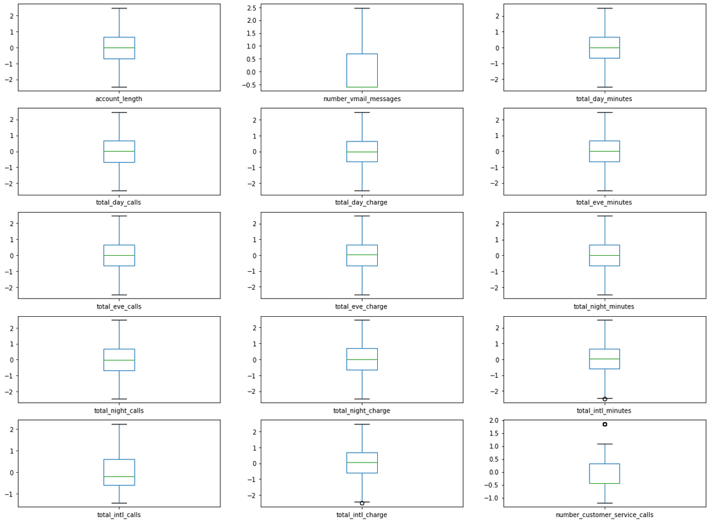

```python
# Boxplot das variáveis numéricas
treino_munging_no_outliers[variaveis_numericas].plot(kind='box', layout=(5,3), subplots=True, figsize=(20,15))
plt.show()
```

De acordo com os gráficos acima, foram removidos os outliers do dataset.

```python
# Exibir primeiras linhas do dataset
treino_munging_no_outliers.head()
```

|  | state | account_length | area_code | international_plan | voice_mail_plan | number_vmail_messages | total_day_minutes | total_day_calls | total_day_charge | total_eve_minutes | total_eve_calls | total_eve_charge | total_night_minutes | total_night_calls | total_night_charge | total_intl_minutes | total_intl_calls | total_intl_charge | number_customer_service_calls | churn |
| --- | --- | --- | --- | --- | --- | --- | --- | --- | --- | --- | --- | --- | --- | --- | --- | --- | --- | --- | --- | --- |
| 0 | 16 | 0.676489 | 1 | 0 | 1 | 1.234883 | 1.566767 | 0.476643 | 1.567036 | -0.070610 | -0.055940 | -0.070427 | 0.866743 | -0.465494 | 0.866029 | -0.085008 | -0.601195 | -0.085690 | -0.427932 | 0 |
| 1 | 35 | 0.149065 | 1 | 0 | 1 | 1.307948 | -0.333738 | 1.124503 | -0.334013 | -0.108080 | 0.144867 | -0.107549 | 1.058571 | 0.147825 | 1.059390 | 1.240482 | -0.601195 | 1.241169 | -0.427932 | 0 |
| 2 | 31 | 0.902529 | 1 | 0 | 0 | -0.591760 | 1.168304 | 0.675985 | 1.168464 | -1.573383 | 0.496279 | -1.573900 | -0.756869 | 0.198935 | -0.755571 | 0.703121 | 0.211534 | 0.697156 | -1.188218 | 0 |
| 4 | 36 | -0.654629 | 1 | 1 | 0 | -0.591760 | -0.240090 | 0.626149 | -0.240041 | -1.038932 | 1.098699 | -1.037939 | -0.276311 | 1.067803 | -0.276562 | -0.049184 | -0.601195 | -0.045885 | 1.092641 | 0 |
| 5 | 1 | 0.425335 | 2 | 1 | 0 | -0.591760 | 0.801056 | -0.121381 | 0.801216 | 0.386928 | 0.044463 | 0.386648 | 0.059881 | 0.914473 | 0.061821 | -1.410498 | 0.617898 | -1.412550 | -1.188218 | 0 |

```python
# Dimensões do dataset
treino_munging_no_outliers.shape
```

```
(2819, 20)
```

O dataset continua com uma boa quantidade de registros para o treinamento do modelo de machine learning, foram removidos 514 registros ao eliminar os outliers das variáveis numéricas.

## 5.0 - Feature Selection (Seleção de variáveis)

```python
# Utilizar o método SelectKBest do SKLearn com o método estatistico f_classif (ANOVA) para selecionas as melhores variáveis para o modelo de machine learning
predict = treino_munging_no_outliers.drop(["churn"], axis = 1)
target = treino_munging_no_outliers["churn"]

kbest = SelectKBest(f_classif, k=15)
kbest.fit_transform(
    X = predict,
    y = target)
print("Concluído treinamento do SelectKBest com método ANOVA")
```

```
Concluído treinamento do SelectKBest com método ANOVA
```

```python
# Criar dataframe com o resultado da seleção de variáveis
resultado_fs = pd.DataFrame({
    'Variavel': predict.columns,
    'Selecionado': kbest.get_support(),
    'Score': kbest.scores_
}).sort_values("Score", ascending = False).reset_index().drop("index", axis = 1)
```

```python
# 8 variáveis com mais score para o treinamento do modelo
variaveis_predict = resultado_fs.iloc[0:8].Variavel.values
```

```python
# Manter somente as variáveis que foram selecionadas na lista de variáveis numéricas
variaveis_numericas_novas = []

for i in variaveis_numericas.copy():
    if ( i in variaveis_predict ):
        variaveis_numericas_novas.append(i)

variaveis_numericas = variaveis_numericas_novas.copy()
```

```python
# Exibir variaveis preditoras selecionadas
variaveis_predict
```

```
array(['international_plan', 'total_day_minutes', 'total_day_charge',
       'number_customer_service_calls', 'total_eve_minutes',
       'total_eve_charge', 'voice_mail_plan', 'number_vmail_messages'],
      dtype=object)
```

As variaveis exibidas acima serão utilizadas para o treinamento do modelo de machine learning porque são as variáveis que tiveram mais score na seleção de variáveis

## 6.0 - Preparar dataset de treino e teste para o treinamento

```python
# Primeiras linhas do dataset de teste
teste_raw.head()
```

|  | Unnamed: 0 | state | account_length | area_code | international_plan | voice_mail_plan | number_vmail_messages | total_day_minutes | total_day_calls | total_day_charge | total_eve_minutes | total_eve_calls | total_eve_charge | total_night_minutes | total_night_calls | total_night_charge | total_intl_minutes | total_intl_calls | total_intl_charge | number_customer_service_calls | churn |
| --- | --- | --- | --- | --- | --- | --- | --- | --- | --- | --- | --- | --- | --- | --- | --- | --- | --- | --- | --- | --- | --- |
| 0 | 1 | HI | 101 | area_code_510 | no | no | 0 | 70.9 | 123 | 12.05 | 211.9 | 73 | 18.01 | 236.0 | 73 | 10.62 | 10.6 | 3 | 2.86 | 3 | no |
| 1 | 2 | MT | 137 | area_code_510 | no | no | 0 | 223.6 | 86 | 38.01 | 244.8 | 139 | 20.81 | 94.2 | 81 | 4.24 | 9.5 | 7 | 2.57 | 0 | no |
| 2 | 3 | OH | 103 | area_code_408 | no | yes | 29 | 294.7 | 95 | 50.10 | 237.3 | 105 | 20.17 | 300.3 | 127 | 13.51 | 13.7 | 6 | 3.70 | 1 | no |
| 3 | 4 | NM | 99 | area_code_415 | no | no | 0 | 216.8 | 123 | 36.86 | 126.4 | 88 | 10.74 | 220.6 | 82 | 9.93 | 15.7 | 2 | 4.24 | 1 | no |
| 4 | 5 | SC | 108 | area_code_415 | no | no | 0 | 197.4 | 78 | 33.56 | 124.0 | 101 | 10.54 | 204.5 | 107 | 9.20 | 7.7 | 4 | 2.08 | 2 | no |

```python
# Tratar o dataset de teste
teste_munging = tratar_dados(teste_raw)
```

```
Concluído remoção da variável 'Unnamed: 0'
Concluído LabelEncoder da variável state
Concluído LabelEncoder da variável area_code
Concluído LabelEncoder da variável international_plan
Concluído LabelEncoder da variável voice_mail_plan
Concluído LabelEncoder da variável churn
Concluído normalização das variáveis numéricas
```

```python
# Manter somente variáveis da feature selection (seleção de variáveis) nos datasets e separar dados de treino e de teste #

# Dataset de treino
x_treino = treino_munging_no_outliers[variaveis_predict]
y_treino = treino_munging_no_outliers["churn"]

# Dataset de teste
x_teste = teste_munging[variaveis_predict]
y_teste = teste_munging["churn"]
```

```python
# Primeiras linhas do dataset de teste sem a variável target após o tratamento dos dados
x_teste.head()
```

|  | international_plan | total_day_minutes | total_day_charge | number_customer_service_calls | total_eve_minutes | total_eve_charge | voice_mail_plan | number_vmail_messages |
| --- | --- | --- | --- | --- | --- | --- | --- | --- |
| 0 | 0 | -2.094534 | -2.094945 | 1.098405 | 0.237980 | 0.237578 | 0 | -0.534172 |
| 1 | 0 | 0.802100 | 0.801816 | -1.231163 | 0.893126 | 0.893550 | 0 | -0.534172 |
| 2 | 0 | 2.150828 | 2.150886 | -0.454641 | 0.743776 | 0.743613 | 1 | 1.657600 |
| 3 | 0 | 0.673108 | 0.673493 | -0.454641 | -1.464604 | -1.465605 | 0 | -0.534172 |
| 4 | 0 | 0.305101 | 0.305261 | 0.321882 | -1.512396 | -1.512460 | 0 | -0.534172 |

```python
# Balancear dataset de treino
x_treino_balanceado, y_treino_balanceado = SMOTE().fit_resample(x_treino, y_treino)
```

```python
# Dimensões do dataset de treino balanceado
print("Dimensões das variáveis preditoras:", x_treino_balanceado.shape)
print("Quantidade de registros da variável target:", y_treino_balanceado.count())
```

```
Dimensões das variáveis preditoras: (4940, 8)
Quantidade de registros da variável target: 4940
```

Dataset está com 4940 registros, com 8 variáveis preditoras e uma variável target após o balanceamento da classe target.

## 7.0 - Treinamento do Modelo de Machine Learning

```python
def obter_modelos():
    modelos = []
    modelos.append( ("Naive Bayes", GaussianNB()) )
    modelos.append( ("Regressão Logística", LogisticRegression()) )
    modelos.append( ("KNN", KNeighborsClassifier()) )
    modelos.append( ("SVM Classificador", SVC()) )

    return modelos
```

```python
# Treinar modelos de regressão logistica e naive bayes com a técnica de cross validation
modelos = obter_modelos()
k = KFold(n_splits=10)

for nome, modelo in modelos:
    cv = cross_validate(estimator = modelo,
                        X = x_treino_balanceado,
                        y = y_treino_balanceado,
                        cv = k,
                        scoring=['accuracy', 'recall', 'precision'])
    print( "%s:\n\tAcurácia: %.3f \n\tRecall: %.3f \n\tPrecisão: %.3f \n" %
          ( nome,
            np.mean(cv["test_accuracy"]),
            np.mean(cv["test_recall"]),
            np.mean(cv["test_precision"])) )
```

```
Naive Bayes:
	Acurácia: 0.722
	Recall: 0.727
	Precisão: 0.615

Regressão Logística:
	Acurácia: 0.694
	Recall: 0.742
	Precisão: 0.599

KNN:
	Acurácia: 0.880
	Recall: 0.931
	Precisão: 0.692

SVM Classificador:
	Acurácia: 0.852
	Recall: 0.823
	Precisão: 0.735
```

Os modelos que apresentaram melhores resultados foram KNN e SVM, vamos realizar treinamento desses modelos individualmente para serem avaliados com dados de teste.

```python
# Treinamento do modelo KNN
modelo_knn_v1 = KNeighborsClassifier()
modelo_knn_v1.probability=True
modelo_knn_v1.fit(X = x_treino_balanceado, y = y_treino_balanceado)
print("Concluído treinamento do algoritmo KNN")
```

```
Concluído treinamento do algoritmo KNN
```

```python
# Treinamento do modelo SVM Classifier
modelo_svm_v1 = SVC()
modelo_svm_v1.probability=True
modelo_svm_v1.fit(X = x_treino_balanceado, y = y_treino_balanceado)
print("Concluído treinamento do algoritmo SVM")
```

```
Concluído treinamento do algoritmo SVM
```

## 8.0 - Avaliação do Modelo de Machine Learning

Métricas escolhida para avalição do modelo: Recall

```python
# Avaliação do modelo KNN com os dados de teste
previsao_knn_v1 = modelo_knn_v1.predict(x_teste)
print( "Avaliação do modelo KNN:\n" )
print( classification_report(y_teste, previsao_knn_v1) )
```

```
Avaliação do modelo KNN:

              precision    recall  f1-score   support

           0       0.96      0.85      0.90      1443
           1       0.44      0.75      0.55       224

    accuracy                           0.84      1667
   macro avg       0.70      0.80      0.73      1667
weighted avg       0.89      0.84      0.85      1667
```

```python
# Avaliação do modelo SVM com os dados de teste
previsao_svm_v1 = modelo_svm_v1.predict(x_teste)
print( "Avaliação do modelo SVM:\n" )
print( classification_report(y_teste, previsao_svm_v1) )
```

```
Avaliação do modelo SVM:

              precision    recall  f1-score   support

           0       0.97      0.90      0.93      1443
           1       0.55      0.82      0.66       224

    accuracy                           0.88      1667
   macro avg       0.76      0.86      0.79      1667
weighted avg       0.91      0.88      0.89      1667
```

O modelo SVM foi superior na métrica recall, esse modelo é o escolhido para receber otimização de hiperparametros.

## 9.0 - Otimização do Modelo de Machine Learning

```python
# Treinar modelo Random Forest para realizar otimização
modelo_rfc_v1 = RandomForestClassifier(n_estimators=1000)
modelo_rfc_v1.fit(x_treino_balanceado, y_treino_balanceado)
print("Concluído treinamento do algoritmo Random Forest")
```

```
Concluído treinamento do algoritmo Random Forest
```

```python
# Avaliação do modelo Random Forest com os dados de teste
previsao_rfc_v1 = modelo_rfc_v1.predict(x_teste)
print( "Avaliação do modelo Random Forest Classifier:\n" )
print( classification_report(y_teste, previsao_rfc_v1) )
```

```
Avaliação do modelo Random Forest Classifier:

              precision    recall  f1-score   support

           0       0.95      0.90      0.93      1443
           1       0.52      0.71      0.60       224

    accuracy                           0.87      1667
   macro avg       0.74      0.80      0.76      1667
weighted avg       0.89      0.87      0.88      1667
```

O modelo Random Forest não teve um recall superior ao modelo SVM.

```python
# Treinar modelo XGBoost para realizar otimização
modelo_xgb_v1 = XGBClassifier(n_estimators=500)
modelo_xgb_v1.fit(x_treino_balanceado, y_treino_balanceado)
print("Concluído treinamento do algoritmo XGBoost")
```

```
[17:38:52] WARNING: C:/Users/Administrator/workspace/xgboost-win64_release_1.4.0/src/learner.cc:1095: Starting in XGBoost 1.3.0, the default evaluation metric used with the objective 'binary:logistic' was changed from 'error' to 'logloss'. Explicitly set eval_metric if you'd like to restore the old …
Concluído treinamento do algoritmo XGBoost
```

```python
# Avaliação do modelo XGBoost com os dados de teste
previsao_xgb_v1 = modelo_xgb_v1.predict(x_teste)
previsao_xgb_v1 = [round(value) for value in previsao_xgb_v1]
print( "Avaliação do modelo XGBoost Classifier:\n" )
print( classification_report(y_teste, previsao_xgb_v1) )
```

```
Avaliação do modelo XGBoost Classifier:

              precision    recall  f1-score   support

           0       0.95      0.47      0.63      1443
           1       0.20      0.85      0.32       224

    accuracy                           0.52      1667
   macro avg       0.58      0.66      0.48      1667
weighted avg       0.85      0.52      0.59      1667
```

```python
# Otimizar hiperparametros do modelo SVM com GridSearchCV #

# Parametros do Grid
param_grid = {'C': [0.1],
              'kernel': ['rbf'],
              'gamma': ['scale'],
              'tol': [0.001],
              'class_weight': [{0:1.0, 1:1.10}, {0:1.0, 1:1.12}]
             }

# Treinar GridSearchCV
grid = GridSearchCV(SVC(), param_grid, refit=True, verbose=2, cv=KFold(n_splits=6), scoring='recall')
grid.fit(x_treino_balanceado, y_treino_balanceado)
```

```
Fitting 6 folds for each of 2 candidates, totalling 12 fits
[CV] END C=0.1, class_weight={0: 1.0, 1: 1.1}, gamma=scale, kernel=rbf, tol=0.001; total time=   1.2s
[CV] END C=0.1, class_weight={0: 1.0, 1: 1.1}, gamma=scale, kernel=rbf, tol=0.001; total time=   1.2s
[CV] END C=0.1, class_weight={0: 1.0, 1: 1.1}, gamma=scale, kernel=rbf, tol=0.001; total time=   1.2s
[CV] END C=0.1, class_weight={0: 1.0, 1: 1.1}, gamma=scale, kernel=rbf, tol=0.001; total time=   1.2s
[CV] END C=0.1, class_weight={0: 1.0, 1: 1.1}, gamma=scale, kernel=rbf, tol=0.001; total time=   1.1s
[CV] END C=0.1, class_weight={0: 1.0, 1: 1.1}, gamma=scale, kernel=rbf, tol=0.001; total time=   1.1s
[CV] END C=0.1, class_weight={0: 1.0, 1: 1.12}, gamma=scale, kernel=rbf, tol=0.001; total time=   1.2s
[CV] END C=0.1, class_weight={0: 1.0, 1: 1.12}, gamma=scale, kernel=rbf, tol=0.001; total time=   1.2s
[CV] END C=0.1, class_weight={0: 1.0, 1: 1.12}, gamma=scale, kernel=rbf, tol=0.001; total time=   1.2s
[CV] END C=0.1, class_weight={0: 1.0, 1: 1.12}, gamma=scale, kernel=rbf, tol=0.001; total time=   1.2s
[CV] END C=0.1, class_weight={0: 1.0, 1: 1.12}, gamma=scale, kernel=rbf, tol=0.001; total time=   1.1s
[CV] END C=0.1, class_weight={0: 1.0, 1: 1.12}, gamma=scale, kernel=rbf, tol=0.001; total time=   1.1s
```

```
GridSearchCV(cv=KFold(n_splits=6, random_state=None, shuffle=False),
             estimator=SVC(),
             param_grid={'C': [0.1],
                         'class_weight': [{0: 1.0, 1: 1.1}, {0: 1.0, 1: 1.12}],
                         'gamma': ['scale'], 'kernel': ['rbf'],
                         'tol': [0.001]},
             scoring='recall', verbose=2)
```

```python
# Exibir melhores parametros encontrados com o GridSearchCV
print("Melhores parametros:")
print(grid.best_params_)
```

```
Melhores parametros:
{'C': 0.1, 'class_weight': {0: 1.0, 1: 1.12}, 'gamma': 'scale', 'kernel': 'rbf', 'tol': 0.001}
```

```python
pd.DataFrame(grid.cv_results_).sort_values(["rank_test_score"]).head()
```

|  | mean_fit_time | std_fit_time | mean_score_time | std_score_time | param_C | param_class_weight | param_gamma | param_kernel | param_tol | params | split0_test_score | split1_test_score | split2_test_score | split3_test_score | split4_test_score | split5_test_score | mean_test_score | std_test_score | rank_test_score |
| --- | --- | --- | --- | --- | --- | --- | --- | --- | --- | --- | --- | --- | --- | --- | --- | --- | --- | --- | --- |
| 1 | 0.949558 | 0.033804 | 0.318936 | 0.012534 | 0.1 | {0: 1.0, 1: 1.12} | scale | rbf | 0.001 | {'C': 0.1, 'class_weight': {0: 1.0, 1: 1.12}, ... | 0.841463 | 0.80198 | 0.855932 | 0.8413 | 0.798299 | 0.778858 | 0.819639 | 0.027967 | 1 |
| 0 | 0.951492 | 0.043893 | 0.321918 | 0.009735 | 0.1 | {0: 1.0, 1: 1.1} | scale | rbf | 0.001 | {'C': 0.1, 'class_weight': {0: 1.0, 1: 1.1}, '... | 0.841463 | 0.80198 | 0.855932 | 0.8413 | 0.797084 | 0.776428 | 0.819031 | 0.028718 | 2 |

```python
# Avaliar modelo treinado com GridSearchCV utilizando os dados de teste
grid_previsoes = grid.predict(x_teste)
print( "Matriz de confusão:\n" )
print( confusion_matrix(y_teste, grid_previsoes) )
print( "\nRelatório de classificação:\n" )
print( classification_report(y_teste, grid_previsoes) )
```

```
Matriz de confusão:

[[1232  211]
 [  27  197]]

Relatório de classificação:

              precision    recall  f1-score   support

           0       0.98      0.85      0.91      1443
           1       0.48      0.88      0.62       224

    accuracy                           0.86      1667
   macro avg       0.73      0.87      0.77      1667
weighted avg       0.91      0.86      0.87      1667
```

## 10.0 - Salvar o Modelo de Machine Learning para Entrega Final do Projeto

```python
# Treinamento do modelo final
modelo_svm_final = SVC(C=0.1, class_weight={0:1.0, 1:1.12}, gamma='scale', kernel='rbf', tol=0.001)
modelo_svm_final.probability = True
modelo_svm_final.fit(x_treino_balanceado, y_treino_balanceado)
print( "Treinamento do Modelo SVM (Versão final) realizado com sucesso" )
```

```
Treinamento do Modelo SVM (Versão final) realizado com sucesso
```

```python
# Prever resultado de Churn e a probabilidade para os dados de teste
previsao_modelo_svm_final = modelo_svm_final.predict(x_teste)
previsao_prob_modelo_svm_final = modelo_svm_final.predict_proba(x_teste)
df_previsoes = pd.DataFrame({
    'churn': pd.Series(previsao_modelo_svm_final, dtype=np.int32),
    'Probabilidade_ChurnNo': pd.Series(np.round(previsao_prob_modelo_svm_final.transpose()[0], 2), dtype=np.float32),
    'Probabilidade_ChurnYes': pd.Series(np.round(previsao_prob_modelo_svm_final.transpose()[1], 2), dtype=np.float32)
})
```

```python
# Dataset de teste com a previsão e probabilidade de churn
teste_resultado = inverter_dados(x_teste.join(df_previsoes))
teste_resultado.head()
```

```
O dataset não tem a variável state
O dataset não tem a variável area_code
Concluído inversão de LabelEncoder da variável international_plan
Concluído inversão de LabelEncoder da variável voice_mail_plan
Concluído inversão de LabelEncoder da variável churn
```

|  | international_plan | total_day_minutes | total_day_charge | number_customer_service_calls | total_eve_minutes | total_eve_charge | voice_mail_plan | number_vmail_messages | churn | Probabilidade_ChurnNo | Probabilidade_ChurnYes |
| --- | --- | --- | --- | --- | --- | --- | --- | --- | --- | --- | --- |
| 0 | no | 70.9 | 12.05 | 3.0 | 211.9 | 18.01 | no | 0.0 | no | 0.58 | 0.42 |
| 1 | no | 223.6 | 38.01 | 0.0 | 244.8 | 20.81 | no | 0.0 | yes | 0.45 | 0.55 |
| 2 | no | 294.7 | 50.10 | 1.0 | 237.3 | 20.17 | yes | 29.0 | no | 0.72 | 0.28 |
| 3 | no | 216.8 | 36.86 | 1.0 | 126.4 | 10.74 | no | 0.0 | no | 0.93 | 0.07 |
| 4 | no | 197.4 | 33.56 | 2.0 | 124.0 | 10.54 | no | 0.0 | no | 0.92 | 0.08 |

```python
# Salvar modelo de machine learning
nome_arquivo = "../modelo/modelo_svm_final.sav"
pickle.dump(modelo_svm_final, open(nome_arquivo, 'wb'))
```